# Réunion bilan 13/03/2020

# 1. Calcul de la distinctiveness

## 1.1 ACP sur les traits indiqués par Xavier (variables quantitatives seulement).

```r
source(here::here("R","Before simulations.R"))
source(here::here("R","Analysis_data.R"))
library(FactoMineR)
library(factoextra)
```

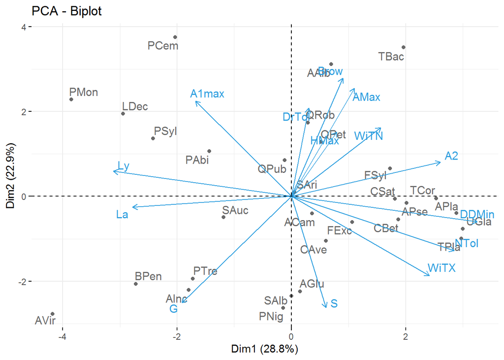

```r
SITE <- c("Bern","Bever","Cottbus","Huttwil")

# Compute distinctiveness ####
# The distinctiveness calculation that I used
# First, I make a PCA, then I calculate the distinctiveness on the first axis

traits<-read.table(here::here("data","Traits of the species_complete.txt"),header=T)
c1<-choice_traits_1(traits) # data.frame with the traits of the species
ACP1<-PCA(c1,graph=F)
fviz_pca_biplot(ACP1, repel = TRUE, # biplot
                col.var = "#2E9FDF", # Couleur des variables
                col.ind = "#696969"  # Couleur des individus
)
```

Pourcentage de la variance expliqué par les différents axes :

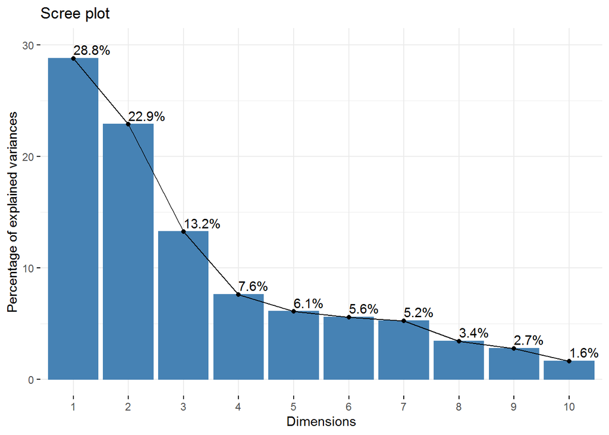

```r
fviz_eig(ACP1, addlabels = TRUE, ylim = c(0, 30))
```

On ne conserve que les quatres premiers axes.

## 1.2 Classement des espèces selon leur distinctiveness

Le classement des espèces est le suivant (ordre de distinctiveness décroissant) :

```r
# position of the species on the first four axis
distACP <- ACP1$ind$coord %>%
  as.data.frame() %>%
  select(Dim.1    ,   Dim.2     ,   Dim.3      ,  Dim.4) %>%
  traits_dist() # computes the distinctiveness
distACP$Name<-traits$Name

distACP[order(distACP$Di,decreasing=T),]$Name
```

```
##  [1] Alnus viridis       Pinus montana       Taxus baccata
##  [4] Abies alba          Pinus cembra        Larix decidua
##  [7] Betula pendula      Quercus robur       Picea abies
## [10] Pinus sylvestris    Populus nigra       Alnus incana
## [13] Ulmus glabra        Tilia platyphyllos  Alnus glutinosa
## [16] Quercus pubescens   Sorbus aria         Populus tremula
## [19] Acer platanoides    Tilia cordata       Salix alba
## [22] Quercus petraea     Corylus avellana    Sorbus aucuparia
## [25] Fagus sylvatica     Acer campestre      Castanea sativa
## [28] Acer pseudoplatanus Fraxinus excelsior  Carpinus betulus
## 30 Levels: Abies alba Acer campestre Acer platanoides ... Ulmus glabra
```

# 2. Distinctiveness et effet des espèces sur les fonctions écosystémiques (“removal experiment”)

# 2.1 Liens entre distinctiveness et richesse

Dans le site de Bern, qui est un site “moyen” :

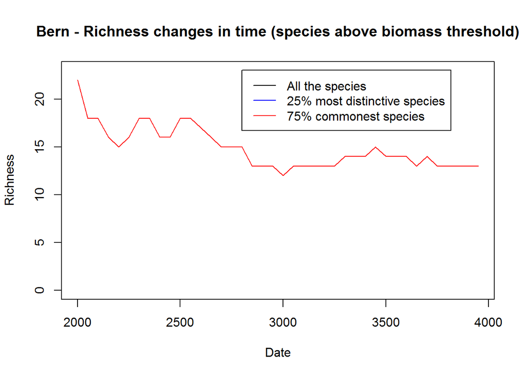

```r
res <- read.table(here::here("data","forceps.Bern.site_1_complete_une simul avec export tout le long.txt"))
colnames(res) <- colnames(read.table(here::here("data","colnames_res.txt"),header=T))
temp_plot <- temporal_plot(res)
temp_threshold <- temporal_plot_threshold(temp_plot)

dist_sp <- distACP[which(distACP$Di>quantile(distACP$Di,0.75)),]$SName # 25% most distinct species
s1 <- subset(temp_threshold,species %in% dist_sp)
s0 <- subset(temp_threshold,!(species %in% dist_sp))

plot(sort(unique(temp_threshold$date)), richness(temp_threshold),type='l',ylim=c(0,23),xlab="Date",ylab="Richness",main="Bern - Richness changes in time (species above biomass threshold)")
lines(sort(unique(s1$date)), richness(s1),type='l',col="blue")
lines(sort(unique(s0$date)), richness(s0),type='l',col="red")
legend(2800, 23, legend=c("All the species", "25% most distinctive species", "75% commonest species"),col=c("black","blue", "red"), lty=1)
```

# 2.2 “Removal experiments”

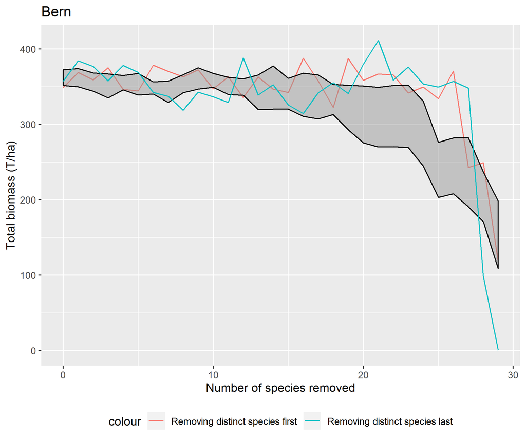

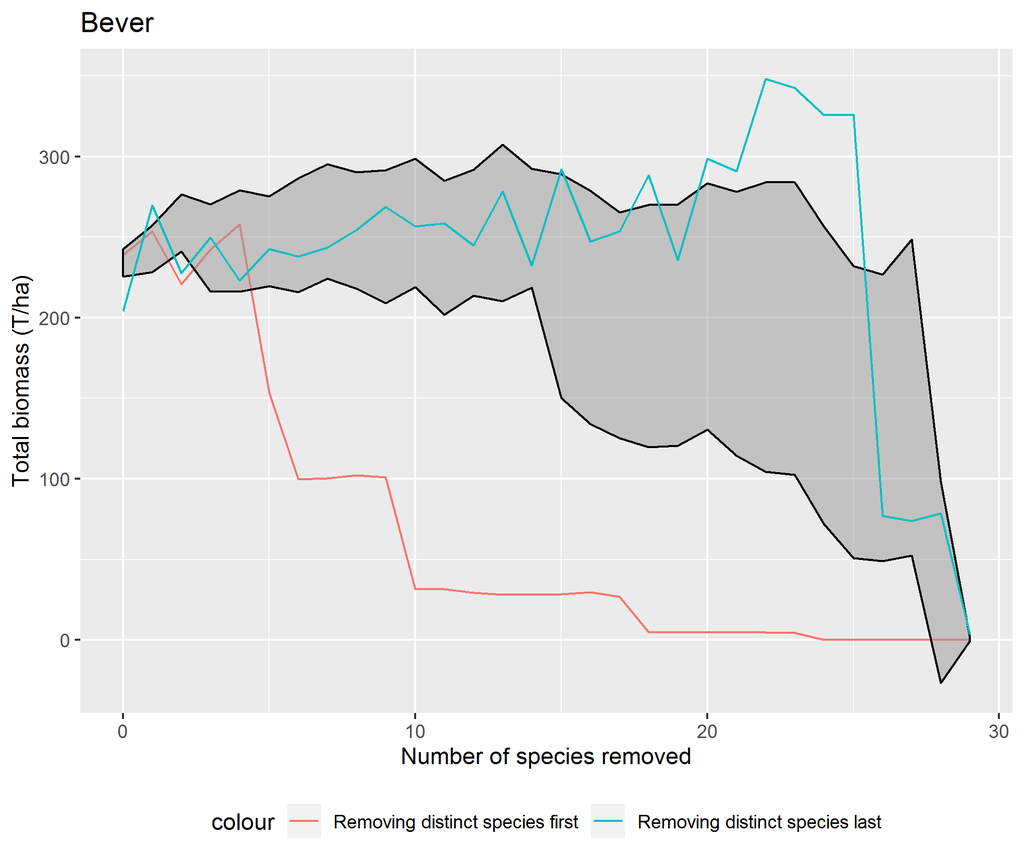

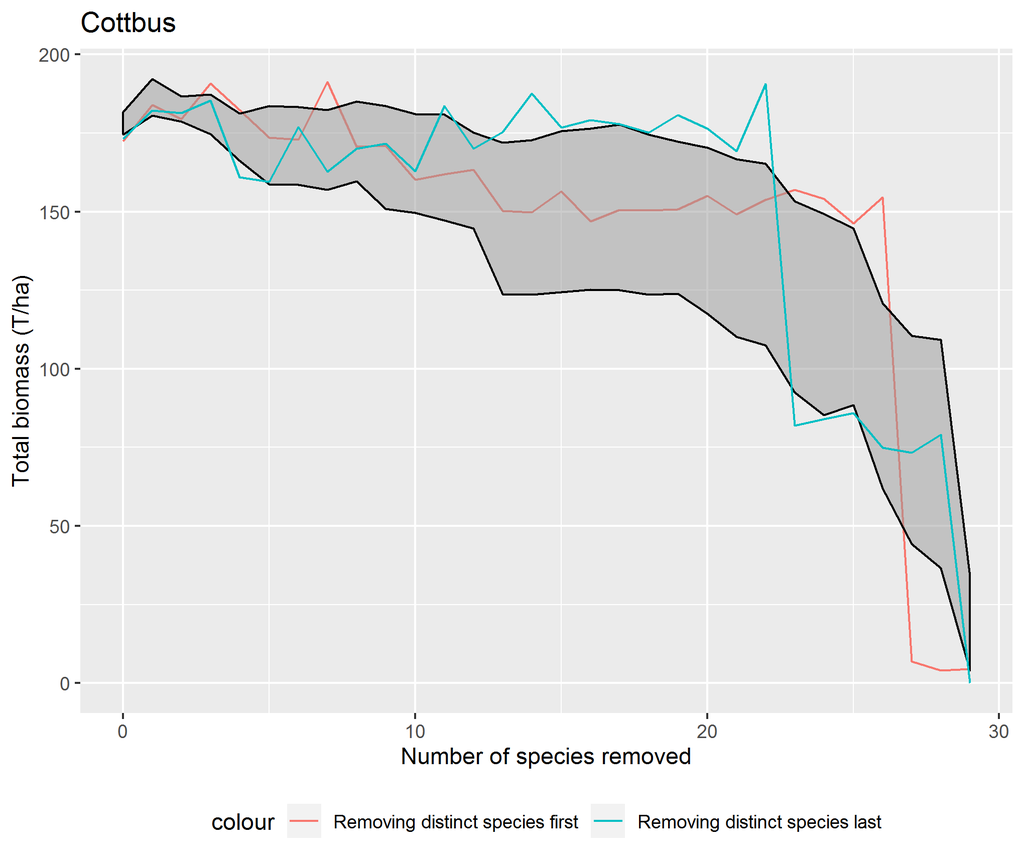

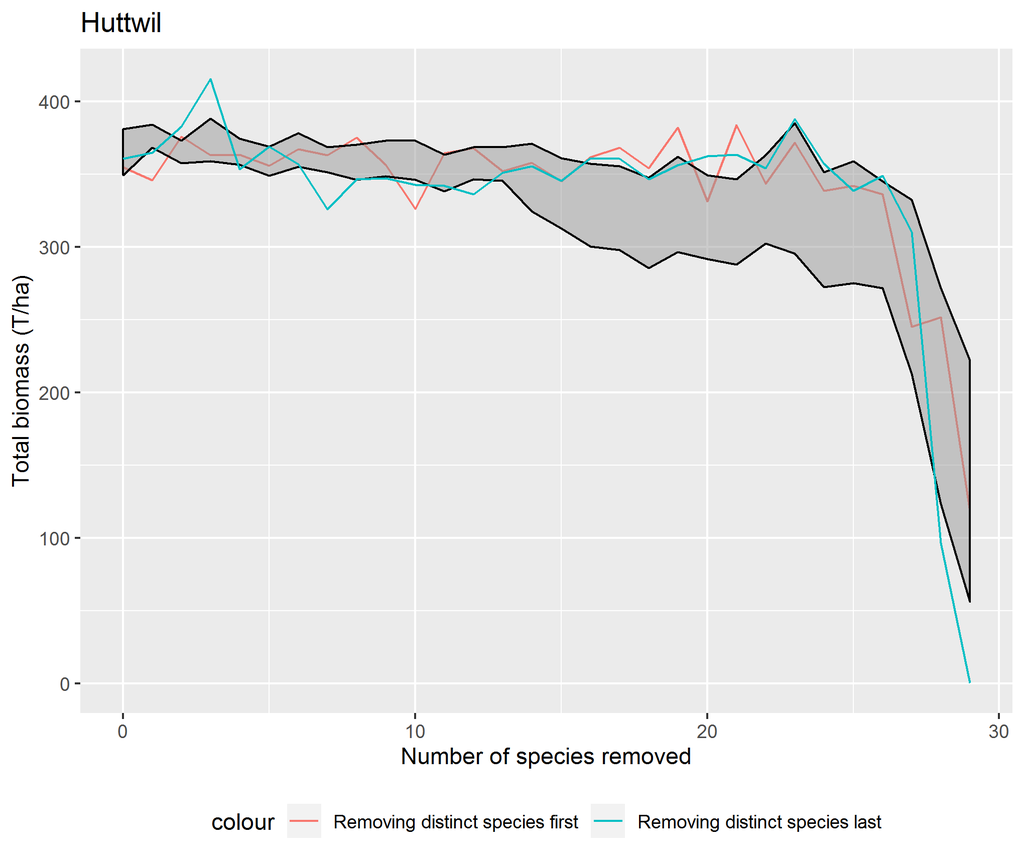

```r
f1 <- here::here("figures","Biomass_Bern.png")
f2 <- here::here("figures","Biomass_Bever.png")
f3 <- here::here("figures","Biomass_Cottbus.png")
f4 <- here::here("figures","Biomass_Huttwil.png")
knitr::include_graphics(c(f1,f2,f3,f4))
```

En fait, le seul cas où on a un effet fort du retrait des espèces distinctes sur la biomasse, c’est quand l’une de celles-ci (en l’occurrence Pinus cembra) est également l’espèce dominante en terme de biomasse dans un site (ici Bever). On retrouve ça dans le papier de Garcia-Valdés. C’est donc de la Mass Ratio Hypothesis toute bête, avec par chance l’espèce dominante dans cet environnement qui est également une espèce distinctive.

On le voit ici, où PCem domine, et n’est pas remplacé quand il est enlevé :

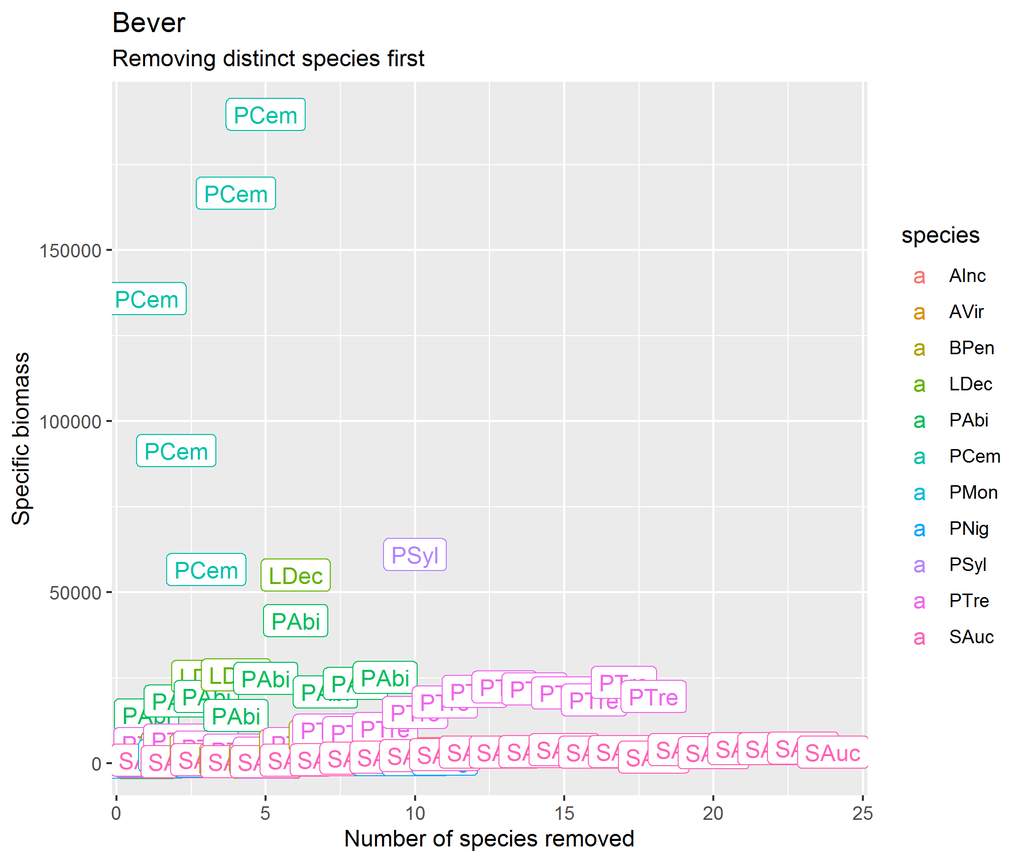

```r
knitr::include_graphics(here::here("figures","specific_biomass_Bever_decreasing.png"))
```

On est donc dans le cas “Dominant distinct traits” du papier de 2017 : une espèce fonctionnellement distinctive est aussi très abondante. Mais on ne peut pas être dans le cas “Scarce distinct traits”, puisqu’une espèce peu abondante aura aussi une faible biomasse, donc une faible valeur de fonction écosystémique. On peut s’intéresser à d’autres propriétés écosystémiques : productivité ou sd(biomass).

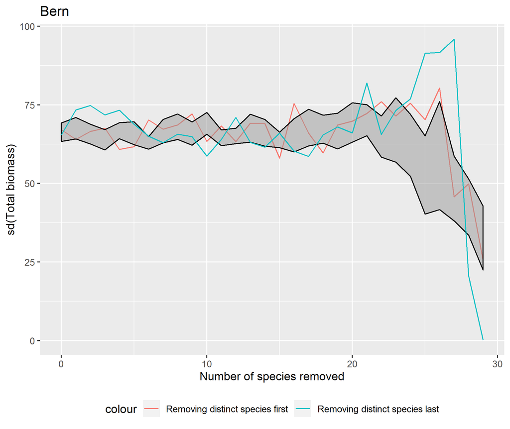

```r
knitr::include_graphics(here::here("figures","sd_biomass_Bern.png"))
```

A part ça, je ne vois pas de patron clair.

Qu’est-ce qu’on attendrait comme effet des espèces distinctes ? Raisonner en effets de complémentarité et sélection ? Le modèle peut-il générer de la complémentarité entre espèces, même dans l’hypothèse où on en trouve en conditions réelles ? Et dans cette hypothèse, qu’est-ce qu’on attend biologiquement ?

# 3. ForCEEPS et CAFE

## 3.1 Comparer deux simulations dans un même environnement, mais avec un pool régional d’espèces plus petit que l’autre.

```r
dat <- read.table(here::here("data/processed/Pairwise_CAFE_values_Huttwil.txt"))
```

### Richesse-Composition

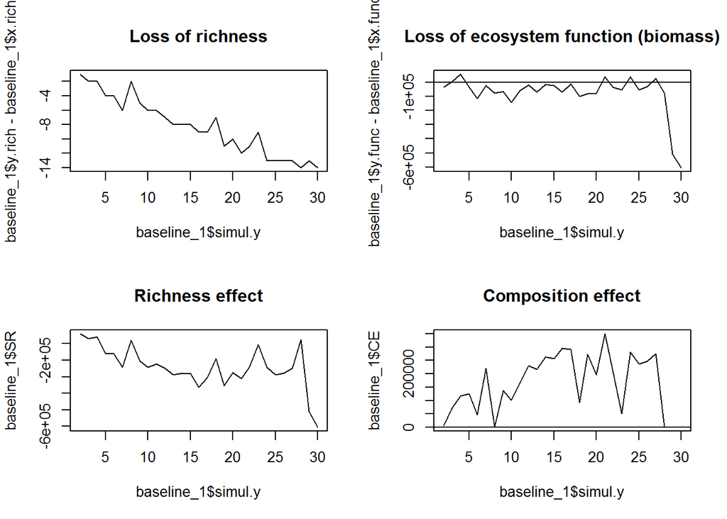

```r
# One order of removal
dats <- subset(dat,order.x=="increasing" & order.y=="increasing")
baseline_1 <- filter(dats,simul.x==1)

par(mfrow=c(2,2))
plot(baseline_1$y.rich - baseline_1$x.rich    ~baseline_1$simul.y,type='l',main="Loss of richness") # Globally, there is a decrease in richness (but with fluctuations) along the simulations.
abline(h=0)
plot(baseline_1$y.func - baseline_1$x.func     ~baseline_1$simul.y,type='l',main="Loss of ecosystem function (biomass)")
abline(h=0)
plot(baseline_1$SR~baseline_1$simul.y,main="Richness effect",type="l")
abline(h=0)
plot(baseline_1$CE~baseline_1$simul.y,main="Composition effect",type="l")
abline(h=0)
```

Analyse de ces graphes :

- La richesse diminue quand on retire des espèces (normal).
- Cependant, la fonction écosystémique diminue assez peu (même : ne diminue pas), au moins avant le retrait de 25 espèces (panel en haut à droite).
- L’effet de la richesse est globalement négatif (en bas à gauche).
- C’est donc un effet de composition (toujours positif) qui compense la perte de richesse : soit on a gardé les “good performers”, soit les espèces restantes ont augmenté leur biomasse individuelle.

Si, maintenant, on enlève les espèces distinctes en premier, l’effet de composition est au départ négatif (en bas à droite). (Et il y a un effet de richesse positif, ce qui est étonnant : on aurait davantage d’espèces présentes à la fin des 2000 ans. Ce qui est possible, puisque j’ai appliqué un seuil sur la biomasse pour qu’une espèce soit considérée comme présente.)

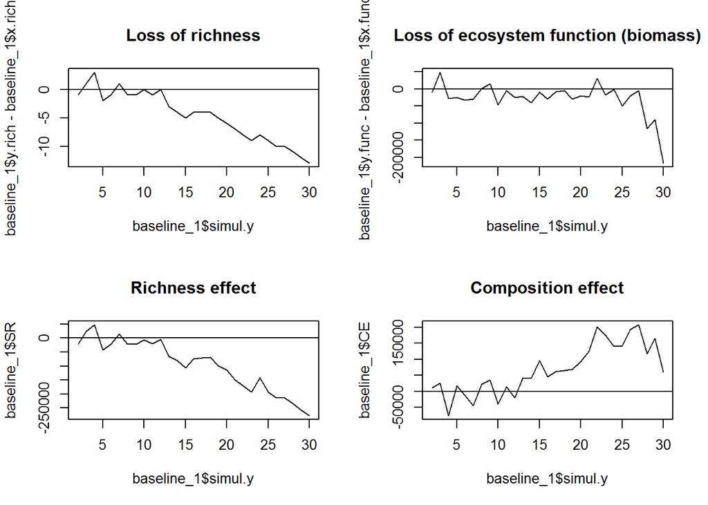

```r
dats <- subset(dat,order.x=="decreasing" & order.y=="decreasing")
baseline_1 <- filter(dats,simul.x==1)

par(mfrow=c(2,2))
plot(baseline_1$y.rich - baseline_1$x.rich    ~baseline_1$simul.y,type='l',main="Loss of richness") # Globally, there is a decrease in richness (but with fluctuations) along the simulations.
abline(h=0)
plot(baseline_1$y.func - baseline_1$x.func     ~baseline_1$simul.y,type='l',main="Loss of ecosystem function (biomass)")
abline(h=0)
plot(baseline_1$SR~baseline_1$simul.y,main="Richness effect",type="l")
abline(h=0)
plot(baseline_1$CE~baseline_1$simul.y,main="Composition effect",type="l")
abline(h=0)
```

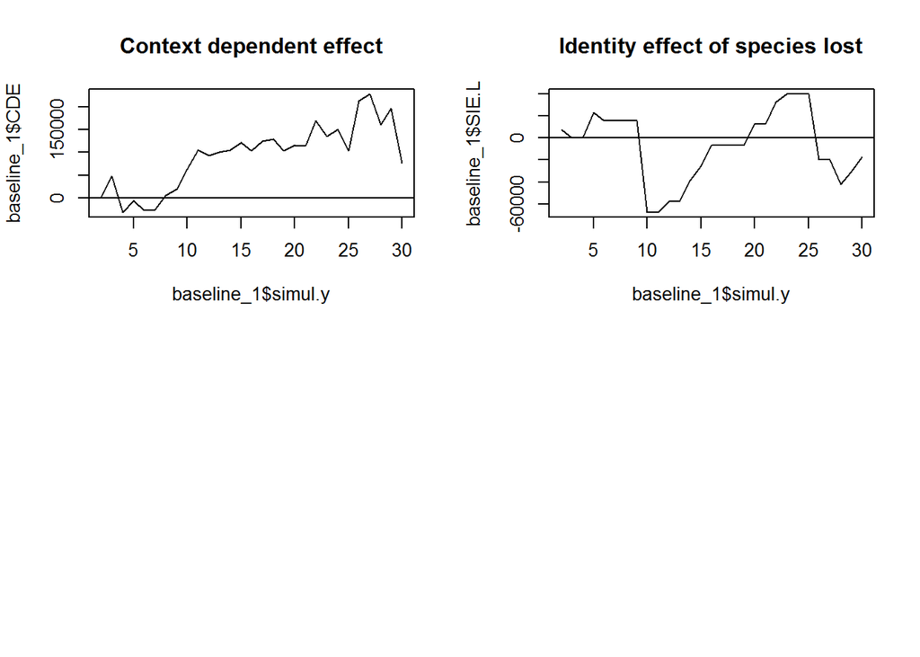

```r
par(mfrow=c(2,2))
plot(baseline_1$CDE~baseline_1$simul.y,main="Context dependent effect",type="l")
abline(h=0)
plot(baseline_1$SIE.L~baseline_1$simul.y,main="Identity effect of species lost",type="l")
abline(h=0)
```

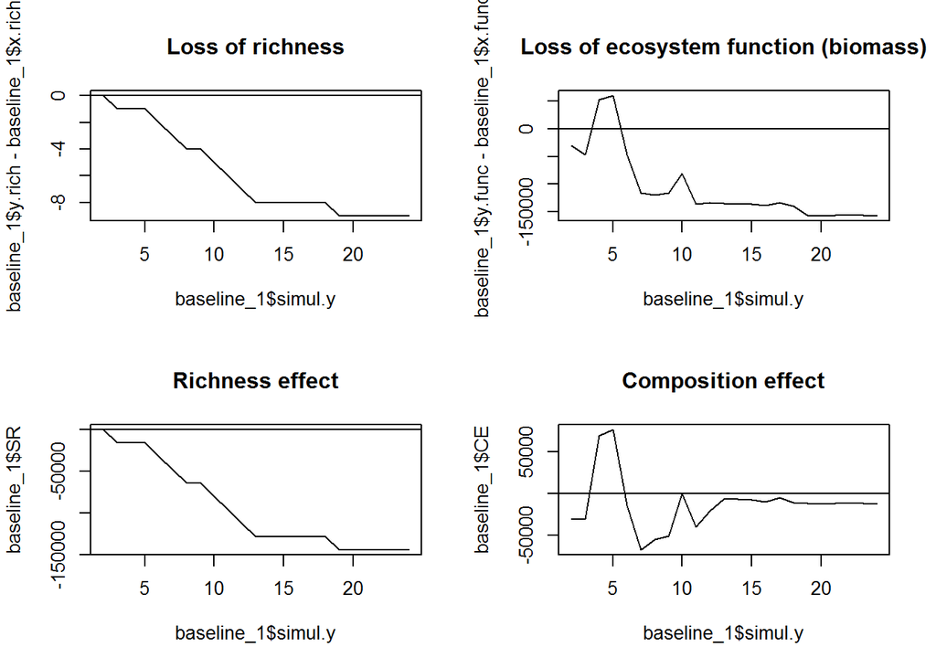

```r
dat <- read.table(here::here("data/processed/Pairwise_CAFE_values_Bever.txt"))

dats <- subset(dat,order.x=="decreasing" & order.y=="decreasing")
baseline_1 <- filter(dats,simul.x==1)

par(mfrow=c(2,2))
plot(baseline_1$y.rich - baseline_1$x.rich    ~baseline_1$simul.y,type='l',main="Loss of richness") # Globally, there is a decrease in richness (but with fluctuations) along the simulations.
abline(h=0)
plot(baseline_1$y.func - baseline_1$x.func     ~baseline_1$simul.y,type='l',main="Loss of ecosystem function (biomass)")
abline(h=0)
plot(baseline_1$SR~baseline_1$simul.y,main="Richness effect",type="l")
abline(h=0)
plot(baseline_1$CE~baseline_1$simul.y,main="Composition effect",type="l")
abline(h=0)
```

```r
dats %>%
  subset(simul.x +1 == simul.y)
```

```
##      simul simul.x    order.x simul.y    order.y      SRE.L SRE.G       SIE.L
## 109    1 2       1 decreasing       2 decreasing      0.000     0       0.000
## 533    2 3       2 decreasing       3 decreasing -13068.397     0   10888.452
## 941    3 4       3 decreasing       4 decreasing      0.000     0       0.000
## 1333   4 5       4 decreasing       5 decreasing      0.000     0       0.000
## 1709   5 6       5 decreasing       6 decreasing -24579.976     0 -165080.111
## 2069   6 7       6 decreasing       7 decreasing -14307.316     0  -40695.845
## 2413   7 8       7 decreasing       8 decreasing  -6381.699     0   -1559.354
## 2741   8 9       8 decreasing       9 decreasing      0.000     0       0.000
## 3053  9 10       9 decreasing      10 decreasing  -7514.173     0  -17532.768
## 3349 10 11      10 decreasing      11 decreasing -16094.383     0  -44866.125
## 3629 11 12      11 decreasing      12 decreasing  -6092.284     0    4906.188
## 3893 12 13      12 decreasing      13 decreasing  -9143.497     0    5967.459
## 4141 13 14      13 decreasing      14 decreasing      0.000     0       0.000
## 4373 14 15      14 decreasing      15 decreasing      0.000     0       0.000
```

[output cut: 57 more lines]

## 3.2 Comparer deux environnements différents ?

# 4. Utilisation des monocultures ?

Comment voir si le fait de retirer certaines espèces peut avoir un effet indirect sur la biomasse d’autres espèces ?

Nos hypothèses biologiques :

- MRH –> quand on retire une espèce de forte biomasse… on perd beaucoup de biomasse (ou de productivité, ou la variance temporelle augmente beaucoup).
- Rareté fonctionnelle –> les espèces les plus distinctes seraient essentielles au fonctionnement de l’écosystème. (A rattacher à l’hypothèse d’assurance, et voir alors en environnement changeant ?)

# 5. Comparer une variation infinitésimale d’un paramètre environnemental (Chris Klausmeier)